[figure not shown]

EN(w/o STI)(diag)-63

Malfunction Indicator Light

ENGINE (DIAGNOSTICS)

15.Malfunction Indicator Light

A: PROCEDURE

1. Activation of malfunction indicator light. <Ref. to EN(w/o STI)(diag)-64, ACTIVATION OF MALFUNCTION INDICATOR LIGHT,

Malfunction Indicator Light.>

↓

2. Malfunction indicator light does not come on. <Ref. to EN(w/o STI)(diag)-65, MALFUNCTION INDICATOR LIGHT DOES NOT

COME ON, Malfunction Indicator Light.>

↓

3. Malfunction indicator light does not go off <Ref. to EN(w/o STI)(diag)-65, MALFUNCTION INDICATOR LIGHT DOES NOT GO

OFF, Malfunction Indicator Light.>

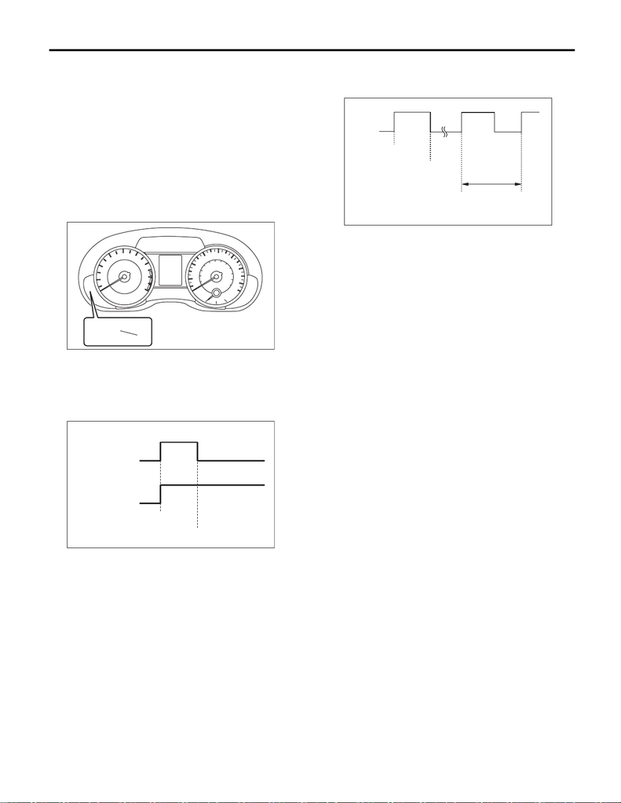

EN(w/o STI)(diag)-64

Malfunction Indicator Light

ENGINE (DIAGNOSTICS)

B: ACTIVATION OF MALFUNCTION

INDICATOR LIGHT

1) When the ignition switch is turned to ON (engine

OFF), the malfunction indicator light in the combi-

nation meter illuminates.

NOTE:

If the malfunction indicator light does not illuminate,

perform diagnostics of the malfunction indicator

light circuit or the combination meter circuit. <Ref.

to EN(w/o STI)(diag)-65, MALFUNCTION INDICA-

TOR LIGHT DOES NOT COME ON, Malfunction

Indicator Light.>

2) After starting the engine, the malfunction indica-

tor light goes out. If it does not go off, any of the en-

gine and emission control system has malfunction.

3) If the diagnostic system detects a misfire which

could damage the catalyst, the malfunction indica-

tor light will blink at a cycle of 1 Hz.

(A) Malfunction indicator light

(1) No DTC

(2) Trouble occurs

(3) ON

(4) OFF

(5) Ignition switch ON

(6) Engine start

(1) ON

(2) OFF

(3) Ignition switch ON

(4) Engine start

(5) Misfire start

(6) 1 second

[figure not shown]

EN(w/o STI)(diag)-65

Malfunction Indicator Light

ENGINE (DIAGNOSTICS)

C: MALFUNCTION INDICATOR LIGHT DOES NOT COME ON

TROUBLE SYMPTOM:

When the ignition switch is turned to ON (engine OFF), malfunction indicator light does not illuminate.

NOTE:

Refer to IDI section for diagnostic procedure. <Ref. to IDI(diag)-2, Basic Diagnostic Procedure.>

D: MALFUNCTION INDICATOR LIGHT DOES NOT GO OFF

TROUBLE SYMPTOM:

Although malfunction indicator light comes on when the engine runs, DTC is not shown on the Subaru Select

Monitor or general scan tool display.

Step Check Yes No

1 CHECK DTC. Is DTC of engine or LAN sys-

tem displayed? <Ref. to EN(w/o

STI)(diag)-46, OPERATION,

Read Diagnostic Trouble Code

(DTC).>

Check the appro-

priate DTC using

the “List of Diag-

nostic Trouble

Code (DTC)”.

<Ref. to EN(w/o

STI)(diag)-85, List

of Diagnostic Trou-

ble Code (DTC).>

<Ref. to

LAN(diag)-70, List

of Diagnostic Trou-

ble Code (DTC).>

Check the combi-

nation meter sys-

tem. <Ref. to

IDI(diag)-2, Basic

Diagnostic Proce-

dure.>